# acchutha

The breast cancer dataset is successfully loaded into Google Colab. The dataset contains diagnostic features used for classifying tumors as benign or malignant.

Prompt: display shape, columns, and information about the dataset

```python
import pandas as pd
from sklearn.datasets import load_breast_cancer

# Load the breast cancer dataset
breast_cancer = load_breast_cancer()
df = pd.DataFrame(data=breast_cancer.data, columns=breast_cancer.feature_names)

print("Shape:", df.shape)

print("\nColumns:")
print(df.columns)

print("\nDataset Info:")
print(df.info())
```

```
Shape: (569, 30)

Columns:
Index(['mean radius', 'mean texture', 'mean perimeter', 'mean area',
       'mean smoothness', 'mean compactness', 'mean concavity',
       'mean concave points', 'mean symmetry', 'mean fractal dimension',
       'radius error', 'texture error', 'perimeter error', 'area error',
       'smoothness error', 'compactness error', 'concavity error',
       'concave points error', 'symmetry error', 'fractal dimension error',
       'worst radius', 'worst texture', 'worst perimeter', 'worst area',
       'worst smoothness', 'worst compactness', 'worst concavity',
       'worst concave points', 'worst symmetry', 'worst fractal dimension'],
      dtype='object')

Dataset Info:
<class 'pandas.core.frame.DataFrame'>
RangeIndex: 569 entries, 0 to 568
Data columns (total 30 columns):
 #   Column                   Non-Null Count  Dtype
---  ------                   --------------  -----
 0   mean radius              569 non-null    float64
 1   mean texture             569 non-null    float64
 2   mean perimeter           569 non-null    float64
 3   mean area                569 non-null    float64
 4   mean smoothness          569 non-null    float64
 5   mean compactness         569 non-null    float64
 6   mean concavity           569 non-null    float64
 7   mean concave points      569 non-null    float64
 8   mean symmetry            569 non-null    float64
 9   mean fractal dimension   569 non-null    float64
 10  radius error             569 non-null    float64
 11  texture error            569 non-null    float64
 12  perimeter error          569 non-null    float64
 13  area error               569 non-null    float64
 14  smoothness error         569 non-null    float64
 15  compactness error        569 non-null    float64
 16  concavity error          569 non-null    float64
 17  concave points error     569 non-null    float64
 18  symmetry error           569 non-null    float64
 19  fractal dimension error  569 non-null    float64
 20  worst radius             569 non-null    float64
 21  worst texture            569 non-null    float64
 22  worst perimeter          569 non-null    float64
 23  worst area               569 non-null    float64
 24  worst smoothness         569 non-null    float64
 25  worst compactness        569 non-null    float64
 26  worst concavity          569 non-null    float64
 27  worst concave points     569 non-null    float64
 28  worst symmetry           569 non-null    float64
 29  worst fractal dimension  569 non-null    float64
dtypes: float64(30)
memory usage: 133.5 KB
None
```

Inference: The dataset contains multiple numerical features related to breast cancer diagnosis. These features are used for machine learning classification.

Prompt: check missing values in the breast cancer dataset

```python
print("Missing values per column:")
print(df.isnull().sum())
```

```
Missing values per column:
mean radius                0
mean texture               0
mean perimeter             0
mean area                  0
mean smoothness            0
mean compactness           0
mean concavity             0
mean concave points        0
mean symmetry              0
mean fractal dimension     0
radius error               0
texture error              0
perimeter error            0
area error                 0
smoothness error           0
compactness error          0
concavity error            0
concave points error       0
symmetry error             0
fractal dimension error    0
worst radius               0
worst texture              0
worst perimeter            0
worst area                 0
worst smoothness           0
worst compactness          0
worst concavity            0
worst concave points       0
worst symmetry             0
worst fractal dimension    0
dtype: int64
```

Inference: No missing values were identified in the dataset. Therefore, no cleaning for missing values is necessary before training machine learning models.

Prompt: remove unnecessary columns and missing values from the dataset

```python
# Drop unnecessary columns if present
if 'Unnamed: 32' in df.columns:
    df = df.drop('Unnamed: 32', axis=1)

if 'id' in df.columns:
    df = df.drop('id', axis=1)

# Remove missing values
df = df.dropna()

print(df.shape)
```

```
(569, 30)
```

Prompt: convert diagnosis labels into numerical values

```python
# Add the target variable (diagnosis labels) to the DataFrame
df['diagnosis'] = breast_cancer.target

# Display the first 5 rows with the new 'diagnosis' column
display(df.head())

# Display the value counts for the 'diagnosis' column
print("\nDiagnosis label counts:")
print(df['diagnosis'].value_counts())
```

|  | mean radius | mean texture | mean perimeter | mean area | mean smoothness | mean compactness | mean concavity | mean concave points | mean symmetry | mean fractal dimension | ... | worst texture | worst perimeter | worst area | worst smoothness | worst compactness | worst concavity | worst concave points | worst symmetry | worst fractal dimension | diagnosis |
| --- | --- | --- | --- | --- | --- | --- | --- | --- | --- | --- | --- | --- | --- | --- | --- | --- | --- | --- | --- | --- | --- |
| 0 | 17.99 | 10.38 | 122.80 | 1001.0 | 0.11840 | 0.27760 | 0.3001 | 0.14710 | 0.2419 | 0.07871 | ... | 17.33 | 184.60 | 2019.0 | 0.1622 | 0.6656 | 0.7119 | 0.2654 | 0.4601 | 0.11890 | 0 |
| 1 | 20.57 | 17.77 | 132.90 | 1326.0 | 0.08474 | 0.07864 | 0.0869 | 0.07017 | 0.1812 | 0.05667 | ... | 23.41 | 158.80 | 1956.0 | 0.1238 | 0.1866 | 0.2416 | 0.1860 | 0.2750 | 0.08902 | 0 |
| 2 | 19.69 | 21.25 | 130.00 | 1203.0 | 0.10960 | 0.15990 | 0.1974 | 0.12790 | 0.2069 | 0.05999 | ... | 25.53 | 152.50 | 1709.0 | 0.1444 | 0.4245 | 0.4504 | 0.2430 | 0.3613 | 0.08758 | 0 |
| 3 | 11.42 | 20.38 | 77.58 | 386.1 | 0.14250 | 0.28390 | 0.2414 | 0.10520 | 0.2597 | 0.09744 | ... | 26.50 | 98.87 | 567.7 | 0.2098 | 0.8663 | 0.6869 | 0.2575 | 0.6638 | 0.17300 | 0 |
| 4 | 20.29 | 14.34 | 135.10 | 1297.0 | 0.10030 | 0.13280 | 0.1980 | 0.10430 | 0.1809 | 0.05883 | ... | 16.67 | 152.20 | 1575.0 | 0.1374 | 0.2050 | 0.4000 | 0.1625 | 0.2364 | 0.07678 | 0 |

5 rows × 31 columns

```
Diagnosis label counts:
diagnosis
1    357
0    212
Name: count, dtype: int64
```

Inference: The diagnosis labels have been successfully converted into numerical values (0 and 1) and added to the DataFrame as a new 'diagnosis' column. '0' typically represents malignant and '1' represents benign in this dataset.

Prompt: visualize feature correlation using heatmap

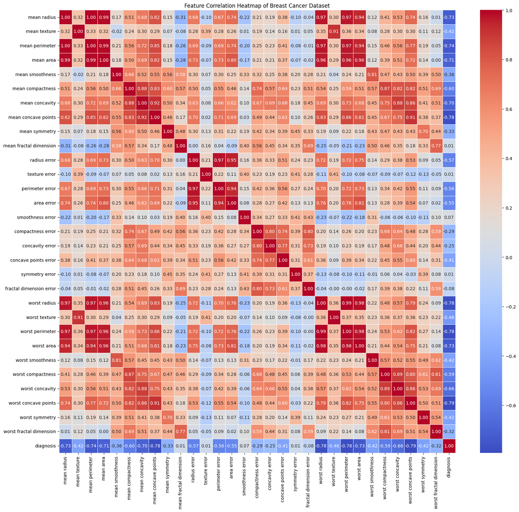

```python
import matplotlib.pyplot as plt
import seaborn as sns

# Calculate the correlation matrix
correlation_matrix = df.corr()

# Plot the heatmap
plt.figure(figsize=(20, 18))
sns.heatmap(correlation_matrix, annot=True, cmap='coolwarm', fmt=".2f", linewidths=.5)
plt.title('Feature Correlation Heatmap of Breast Cancer Dataset')
plt.show()
```

Inference: The heatmap visually represents the correlation coefficients between all pairs of features in the dataset. A value close to 1 indicates a strong positive correlation, a value close to -1 indicates a strong negative correlation, and a value close to 0 indicates a weak or no linear correlation. This visualization helps in identifying highly correlated features, which can be useful for feature selection or understanding multicollinearity.

Prompt: separate input features and target variable

```python
# Separate input features (X) and target variable (y)
X = df.drop('diagnosis', axis=1)
y = df['diagnosis']

print("Shape of X (input features):")
print(X.shape)
print("Shape of y (target variable):")
print(y.shape)

# Display the first few rows of X and y
print("\nFirst 5 rows of X:")
display(X.head())
print("\nFirst 5 values of y:")
display(y.head())
```

```
Shape of X (input features):
(569, 30)
Shape of y (target variable):
(569,)

First 5 rows of X:
```

|  | mean radius | mean texture | mean perimeter | mean area | mean smoothness | mean compactness | mean concavity | mean concave points | mean symmetry | mean fractal dimension | ... | worst radius | worst texture | worst perimeter | worst area | worst smoothness | worst compactness | worst concavity | worst concave points | worst symmetry | worst fractal dimension |
| --- | --- | --- | --- | --- | --- | --- | --- | --- | --- | --- | --- | --- | --- | --- | --- | --- | --- | --- | --- | --- | --- |
| 0 | 17.99 | 10.38 | 122.80 | 1001.0 | 0.11840 | 0.27760 | 0.3001 | 0.14710 | 0.2419 | 0.07871 | ... | 25.38 | 17.33 | 184.60 | 2019.0 | 0.1622 | 0.6656 | 0.7119 | 0.2654 | 0.4601 | 0.11890 |
| 1 | 20.57 | 17.77 | 132.90 | 1326.0 | 0.08474 | 0.07864 | 0.0869 | 0.07017 | 0.1812 | 0.05667 | ... | 24.99 | 23.41 | 158.80 | 1956.0 | 0.1238 | 0.1866 | 0.2416 | 0.1860 | 0.2750 | 0.08902 |
| 2 | 19.69 | 21.25 | 130.00 | 1203.0 | 0.10960 | 0.15990 | 0.1974 | 0.12790 | 0.2069 | 0.05999 | ... | 23.57 | 25.53 | 152.50 | 1709.0 | 0.1444 | 0.4245 | 0.4504 | 0.2430 | 0.3613 | 0.08758 |
| 3 | 11.42 | 20.38 | 77.58 | 386.1 | 0.14250 | 0.28390 | 0.2414 | 0.10520 | 0.2597 | 0.09744 | ... | 14.91 | 26.50 | 98.87 | 567.7 | 0.2098 | 0.8663 | 0.6869 | 0.2575 | 0.6638 | 0.17300 |
| 4 | 20.29 | 14.34 | 135.10 | 1297.0 | 0.10030 | 0.13280 | 0.1980 | 0.10430 | 0.1809 | 0.05883 | ... | 22.54 | 16.67 | 152.20 | 1575.0 | 0.1374 | 0.2050 | 0.4000 | 0.1625 | 0.2364 | 0.07678 |

5 rows × 30 columns

```
First 5 values of y:
```

|  | diagnosis |
| --- | --- |
| 0 | 0 |
| 1 | 0 |
| 2 | 0 |
| 3 | 0 |
| 4 | 0 |

**dtype:** int64

Inference: Input features `X` and target variable `y` have been successfully separated from the dataset. `X` contains all the diagnostic measurements, and `y` contains the corresponding diagnosis (0 for malignant, 1 for benign).

Prompt: standardize dataset features using StandardScaler

```python
from sklearn.preprocessing import StandardScaler

# Initialize the StandardScaler
scaler = StandardScaler()

# Fit the scaler to the features and transform them
X_scaled = scaler.fit_transform(X)

# Convert the scaled array back to a DataFrame for easier inspection
X_scaled_df = pd.DataFrame(X_scaled, columns=X.columns)

print("Shape of X_scaled (standardized input features):")
print(X_scaled_df.shape)

# Display the first few rows of the standardized features
print("\nFirst 5 rows of X_scaled:")
display(X_scaled_df.head())
```

```
Shape of X_scaled (standardized input features):
(569, 30)

First 5 rows of X_scaled:
```

|  | mean radius | mean texture | mean perimeter | mean area | mean smoothness | mean compactness | mean concavity | mean concave points | mean symmetry | mean fractal dimension | ... | worst radius | worst texture | worst perimeter | worst area | worst smoothness | worst compactness | worst concavity | worst concave points | worst symmetry | worst fractal dimension |
| --- | --- | --- | --- | --- | --- | --- | --- | --- | --- | --- | --- | --- | --- | --- | --- | --- | --- | --- | --- | --- | --- |
| 0 | 1.097064 | -2.073335 | 1.269934 | 0.984375 | 1.568466 | 3.283515 | 2.652874 | 2.532475 | 2.217515 | 2.255747 | ... | 1.886690 | -1.359293 | 2.303601 | 2.001237 | 1.307686 | 2.616665 | 2.109526 | 2.296076 | 2.750622 | 1.937015 |
| 1 | 1.829821 | -0.353632 | 1.685955 | 1.908708 | -0.826962 | -0.487072 | -0.023846 | 0.548144 | 0.001392 | -0.868652 | ... | 1.805927 | -0.369203 | 1.535126 | 1.890489 | -0.375612 | -0.430444 | -0.146749 | 1.087084 | -0.243890 | 0.281190 |
| 2 | 1.579888 | 0.456187 | 1.566503 | 1.558884 | 0.942210 | 1.052926 | 1.363478 | 2.037231 | 0.939685 | -0.398008 | ... | 1.511870 | -0.023974 | 1.347475 | 1.456285 | 0.527407 | 1.082932 | 0.854974 | 1.955000 | 1.152255 | 0.201391 |
| 3 | -0.768909 | 0.253732 | -0.592687 | -0.764464 | 3.283553 | 3.402909 | 1.915897 | 1.451707 | 2.867383 | 4.910919 | ... | -0.281464 | 0.133984 | -0.249939 | -0.550021 | 3.394275 | 3.893397 | 1.989588 | 2.175786 | 6.046041 | 4.935010 |
| 4 | 1.750297 | -1.151816 | 1.776573 | 1.826229 | 0.280372 | 0.539340 | 1.371011 | 1.428493 | -0.009560 | -0.562450 | ... | 1.298575 | -1.466770 | 1.338539 | 1.220724 | 0.220556 | -0.313395 | 0.613179 | 0.729259 | -0.868353 | -0.397100 |

5 rows × 30 columns

Inference: The input features (X) have been successfully standardized using `StandardScaler`. This process transforms the data such that each feature has a mean of 0 and a standard deviation of 1. This is a crucial preprocessing step for many machine learning algorithms, especially those that are sensitive to the scale of input features (e.g., SVMs, neural networks, or algorithms using distance metrics).

Prompt: split the dataset into training and testing sets

```python
from sklearn.model_selection import train_test_split

# Split the dataset into training and testing sets
# X_scaled contains the standardized features, y contains the target labels
X_train, X_test, y_train, y_test = train_test_split(X_scaled, y, test_size=0.2, random_state=42)

print("Shape of X_train (training features):")
print(X_train.shape)
print("Shape of X_test (testing features):")
print(X_test.shape)
print("Shape of y_train (training target):")
print(y_train.shape)
print("Shape of y_test (testing target):")
print(y_test.shape)

# Display the first few rows of the training features
print("\nFirst 5 rows of X_train:")
display(pd.DataFrame(X_train, columns=X.columns).head())
```

```
Shape of X_train (training features):
(455, 30)
Shape of X_test (testing features):
(114, 30)
Shape of y_train (training target):
(455,)
Shape of y_test (testing target):
(114,)

First 5 rows of X_train:
```

|  | mean radius | mean texture | mean perimeter | mean area | mean smoothness | mean compactness | mean concavity | mean concave points | mean symmetry | mean fractal dimension | ... | worst radius | worst texture | worst perimeter | worst area | worst smoothness | worst compactness | worst concavity | worst concave points | worst symmetry | worst fractal dimension |
| --- | --- | --- | --- | --- | --- | --- | --- | --- | --- | --- | --- | --- | --- | --- | --- | --- | --- | --- | --- | --- | --- |
| 0 | -1.447987 | -0.456023 | -1.366651 | -1.150124 | 0.728714 | 0.700428 | 2.814833 | -0.133333 | 1.093024 | 2.503828 | ... | -1.234044 | -0.492965 | -1.243893 | -0.977194 | 0.693984 | 1.159269 | 4.700669 | 0.919592 | 2.147190 | 1.859432 |
| 1 | 1.977508 | 1.694187 | 2.089619 | 1.866047 | 1.262455 | 3.389643 | 2.007548 | 2.596960 | 2.129892 | 1.585220 | ... | 2.155897 | 1.270634 | 2.062335 | 2.124291 | 0.733436 | 3.207003 | 1.946890 | 2.675218 | 1.936879 | 2.463465 |
| 2 | -1.407089 | -1.263516 | -1.349763 | -1.120545 | -1.362838 | -0.318972 | -0.363081 | -0.699511 | 1.932741 | 0.968562 | ... | -1.296169 | -1.049890 | -1.241212 | -1.002860 | -1.490797 | -0.550038 | -0.635617 | -0.970486 | 0.616770 | 0.052877 |
| 3 | -0.987600 | 1.380033 | -0.986877 | -0.875668 | 0.014925 | -0.606466 | -0.816190 | -0.845247 | 0.311723 | 0.069801 | ... | -0.832304 | 1.549097 | -0.872165 | -0.746907 | 0.768505 | -0.728158 | -0.766109 | -0.810759 | 0.822228 | -0.137199 |
| 4 | -1.123927 | -1.026155 | -1.129395 | -0.975496 | 1.212639 | -0.449737 | -0.978777 | -0.929077 | 3.400421 | 0.964310 | ... | -1.087016 | -1.339752 | -1.114026 | -0.900022 | -0.213419 | -0.989865 | -1.201820 | -1.352369 | 1.061659 | -0.207578 |

5 rows × 30 columns

Inference: The dataset has been successfully split into training and testing sets. The training set (`X_train`, `y_train`) will be used to train the machine learning models, and the testing set (`X_test`, `y_test`) will be used to evaluate their performance on unseen data. A `test_size` of 20% and a `random_state` of 42 were used for reproducibility.

Prompt: train Logistic Regression model for breast cancer classification

```python
from sklearn.linear_model import LogisticRegression
from sklearn.metrics import accuracy_score, precision_score, recall_score, f1_score, confusion_matrix, classification_report

# Initialize the Logistic Regression model
log_reg_model = LogisticRegression(random_state=42)

# Train the model using the training data
log_reg_model.fit(X_train, y_train)

# Make predictions on the test data
y_pred_log_reg = log_reg_model.predict(X_test)

# Evaluate the model's performance
accuracy_log_reg = accuracy_score(y_test, y_pred_log_reg)
precision_log_reg = precision_score(y_test, y_pred_log_reg)
recall_log_reg = recall_score(y_test, y_pred_log_reg)
f1_log_reg = f1_score(y_test, y_pred_log_reg)
conf_matrix_log_reg = confusion_matrix(y_test, y_pred_log_reg)
class_report_log_reg = classification_report(y_test, y_pred_log_reg)

print(f"Logistic Regression Model Accuracy: {accuracy_log_reg:.4f}")
print(f"Logistic Regression Model Precision: {precision_log_reg:.4f}")
print(f"Logistic Regression Model Recall: {recall_log_reg:.4f}")
print(f"Logistic Regression Model F1-Score: {f1_log_reg:.4f}")

print("\nConfusion Matrix for Logistic Regression:\n", conf_matrix_log_reg)
print("\nClassification Report for Logistic Regression:\n", class_report_log_reg)
```

```
Logistic Regression Model Accuracy: 0.9737
Logistic Regression Model Precision: 0.9722
Logistic Regression Model Recall: 0.9859
Logistic Regression Model F1-Score: 0.9790

Confusion Matrix for Logistic Regression:
 [[41  2]
 [ 1 70]]

Classification Report for Logistic Regression:
               precision    recall  f1-score   support

           0       0.98      0.95      0.96        43
           1       0.97      0.99      0.98        71

    accuracy                           0.97       114
   macro avg       0.97      0.97      0.97       114
weighted avg       0.97      0.97      0.97       114
```

Inference: The Logistic Regression model has been trained and evaluated. The performance metrics (accuracy, precision, recall, F1-score) and the confusion matrix provide insights into how well the model classifies breast cancer as benign (1) or malignant (0). These metrics will be used to assess the model's effectiveness.

Prompt: train KNN model for breast cancer classification

```python
from sklearn.neighbors import KNeighborsClassifier

# Initialize the KNN model
knn_model = KNeighborsClassifier(n_neighbors=5) # Using 5 neighbors as a common starting point

# Train the model using the training data
knn_model.fit(X_train, y_train)

# Make predictions on the test data
y_pred_knn = knn_model.predict(X_test)

# Evaluate the model's performance
accuracy_knn = accuracy_score(y_test, y_pred_knn)
precision_knn = precision_score(y_test, y_pred_knn)
recall_knn = recall_score(y_test, y_pred_knn)
f1_knn = f1_score(y_test, y_pred_knn)
conf_matrix_knn = confusion_matrix(y_test, y_pred_knn)
class_report_knn = classification_report(y_test, y_pred_knn)

print(f"KNN Model Accuracy: {accuracy_knn:.4f}")
print(f"KNN Model Precision: {precision_knn:.4f}")
print(f"KNN Model Recall: {recall_knn:.4f}")
print(f"KNN Model F1-Score: {f1_knn:.4f}")

print("\nConfusion Matrix for KNN:\n", conf_matrix_knn)
print("\nClassification Report for KNN:\n", class_report_knn)
```

```
KNN Model Accuracy: 0.9474
KNN Model Precision: 0.9577
KNN Model Recall: 0.9577
KNN Model F1-Score: 0.9577

Confusion Matrix for KNN:
 [[40  3]
 [ 3 68]]

Classification Report for KNN:
               precision    recall  f1-score   support

           0       0.93      0.93      0.93        43
           1       0.96      0.96      0.96        71

    accuracy                           0.95       114
   macro avg       0.94      0.94      0.94       114
weighted avg       0.95      0.95      0.95       114
```

Inference: The K-Nearest Neighbors (KNN) model has been trained and evaluated. The performance metrics (accuracy, precision, recall, F1-score) and the confusion matrix for the KNN model provide insights into its effectiveness for breast cancer classification. These results can be compared with other models (like Logistic Regression) to determine the best-performing model for this dataset.

Prompt: train Decision Tree model for breast cancer classification

```python
from sklearn.tree import DecisionTreeClassifier

# Initialize the Decision Tree model
dt_model = DecisionTreeClassifier(random_state=42)

# Train the model using the training data
dt_model.fit(X_train, y_train)

# Make predictions on the test data
y_pred_dt = dt_model.predict(X_test)

# Evaluate the model's performance
accuracy_dt = accuracy_score(y_test, y_pred_dt)
precision_dt = precision_score(y_test, y_pred_dt)
recall_dt = recall_score(y_test, y_pred_dt)
f1_dt = f1_score(y_test, y_pred_dt)
conf_matrix_dt = confusion_matrix(y_test, y_pred_dt)
class_report_dt = classification_report(y_test, y_pred_dt)

print(f"Decision Tree Model Accuracy: {accuracy_dt:.4f}")
print(f"Decision Tree Model Precision: {precision_dt:.4f}")
print(f"Decision Tree Model Recall: {recall_dt:.4f}")
print(f"Decision Tree Model F1-Score: {f1_dt:.4f}")

print("\nConfusion Matrix for Decision Tree:\n", conf_matrix_dt)
print("\nClassification Report for Decision Tree:\n", class_report_dt)
```

```
Decision Tree Model Accuracy: 0.9474
Decision Tree Model Precision: 0.9577
Decision Tree Model Recall: 0.9577
Decision Tree Model F1-Score: 0.9577

Confusion Matrix for Decision Tree:
 [[40  3]
 [ 3 68]]

Classification Report for Decision Tree:
               precision    recall  f1-score   support

           0       0.93      0.93      0.93        43
           1       0.96      0.96      0.96        71

    accuracy                           0.95       114
   macro avg       0.94      0.94      0.94       114
weighted avg       0.95      0.95      0.95       114
```

Inference: The Decision Tree model has been trained and evaluated. The performance metrics (accuracy, precision, recall, F1-score) and the confusion matrix for the Decision Tree model provide insights into its effectiveness for breast cancer classification. These results can be compared with the Logistic Regression and KNN models to determine the best-performing model for this dataset.

Prompt: train ANN model using Multilayer Perceptron for breast cancer classification

```python
from sklearn.neural_network import MLPClassifier

# Initialize the MLPClassifier model (a type of ANN)
# Using default parameters, but these can be tuned (e.g., hidden_layer_sizes, activation, solver)
mlp_model = MLPClassifier(random_state=42, max_iter=500) # Increased max_iter for potential convergence

# Train the model using the training data
mlp_model.fit(X_train, y_train)

# Make predictions on the test data
y_pred_mlp = mlp_model.predict(X_test)

# Evaluate the model's performance
accuracy_mlp = accuracy_score(y_test, y_pred_mlp)
precision_mlp = precision_score(y_test, y_pred_mlp)
recall_mlp = recall_score(y_test, y_pred_mlp)
f1_mlp = f1_score(y_test, y_pred_mlp)
conf_matrix_mlp = confusion_matrix(y_test, y_pred_mlp)
class_report_mlp = classification_report(y_test, y_pred_mlp)

print(f"MLP Classifier Model Accuracy: {accuracy_mlp:.4f}")
print(f"MLP Classifier Model Precision: {precision_mlp:.4f}")
print(f"MLP Classifier Model Recall: {recall_mlp:.4f}")
print(f"MLP Classifier Model F1-Score: {f1_mlp:.4f}")

print("\nConfusion Matrix for MLP Classifier:\n", conf_matrix_mlp)
print("\nClassification Report for MLP Classifier:\n", class_report_mlp)
```

```
MLP Classifier Model Accuracy: 0.9737
MLP Classifier Model Precision: 0.9722
MLP Classifier Model Recall: 0.9859
MLP Classifier Model F1-Score: 0.9790

Confusion Matrix for MLP Classifier:
 [[41  2]
 [ 1 70]]

Classification Report for MLP Classifier:
               precision    recall  f1-score   support

           0       0.98      0.95      0.96        43
           1       0.97      0.99      0.98        71

    accuracy                           0.97       114
   macro avg       0.97      0.97      0.97       114
weighted avg       0.97      0.97      0.97       114
```

Inference: The Multilayer Perceptron (MLP) Classifier, a type of Artificial Neural Network, has been trained and evaluated. The performance metrics (accuracy, precision, recall, F1-score) and the confusion matrix for the MLP model provide insights into its effectiveness for breast cancer classification. These results can be compared with the previously trained Logistic Regression, KNN, and Decision Tree models to determine the best-performing model for this dataset.

Prompt: train Support Vector Machine model for breast cancer classification

```python
from sklearn.svm import SVC
from sklearn.metrics import accuracy_score, precision_score, recall_score, f1_score, confusion_matrix, classification_report

# Initialize the SVM model
svm_model = SVC(random_state=42)

# Train the model using the training data
svm_model.fit(X_train, y_train)

# Make predictions on the test data
y_pred_svm = svm_model.predict(X_test)

# Evaluate the model's performance
accuracy_svm = accuracy_score(y_test, y_pred_svm)
precision_svm = precision_score(y_test, y_pred_svm)
recall_svm = recall_score(y_test, y_pred_svm)
f1_svm = f1_score(y_test, y_pred_svm)
conf_matrix_svm = confusion_matrix(y_test, y_pred_svm)
class_report_svm = classification_report(y_test, y_pred_svm)

print(f"SVM Model Accuracy: {accuracy_svm:.4f}")
print(f"SVM Model Precision: {precision_svm:.4f}")
print(f"SVM Model Recall: {recall_svm:.4f}")
print(f"SVM Model F1-Score: {f1_svm:.4f}")

print("\nConfusion Matrix for SVM:\n", conf_matrix_svm)
print("\nClassification Report for SVM:\n", class_report_svm)
```

```
SVM Model Accuracy: 0.9737
SVM Model Precision: 0.9722
SVM Model Recall: 0.9859
SVM Model F1-Score: 0.9790

Confusion Matrix for SVM:
 [[41  2]
 [ 1 70]]

Classification Report for SVM:
               precision    recall  f1-score   support

           0       0.98      0.95      0.96        43
           1       0.97      0.99      0.98        71

    accuracy                           0.97       114
   macro avg       0.97      0.97      0.97       114
weighted avg       0.97      0.97      0.97       114
```

Inference: The Support Vector Machine (SVM) model has been trained and evaluated. The performance metrics (accuracy, precision, recall, F1-score) and the confusion matrix for the SVM model provide insights into its effectiveness for breast cancer classification. These results can be compared with the previously trained models (Logistic Regression, KNN, Decision Tree, and MLP) to determine the best-performing model for this dataset.

Prompt: compare the accuracy of all machine learning models

```python
model_accuracies = {
    'Logistic Regression': accuracy_log_reg,
    'KNN': accuracy_knn,
    'Decision Tree': accuracy_dt,
    'MLP Classifier': accuracy_mlp,
    'SVM': accuracy_svm
}

accuracy_df = pd.DataFrame(model_accuracies.items(), columns=['Model', 'Accuracy'])
accuracy_df = accuracy_df.sort_values(by='Accuracy', ascending=False).reset_index(drop=True)

print("\nAccuracy Comparison of Machine Learning Models:")
display(accuracy_df)
```

```
Accuracy Comparison of Machine Learning Models:
```

|  | Model | Accuracy |
| --- | --- | --- |
| 0 | Logistic Regression | 0.973684 |
| 1 | SVM | 0.973684 |
| 2 | MLP Classifier | 0.973684 |
| 3 | Decision Tree | 0.947368 |
| 4 | KNN | 0.947368 |

Inference: The comparison of accuracy scores shows that Logistic Regression, MLP Classifier, and SVM models achieved the highest accuracy (0.9737), closely followed by KNN and Decision Tree models (0.9474). This suggests that for this breast cancer dataset, linear models and more complex non-linear models like ANN and SVM perform very well after feature standardization.

Prompt: visualize model accuracy comparison using bar graph

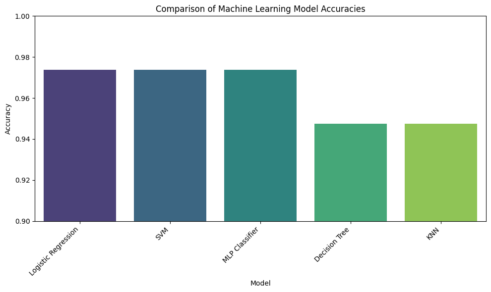

```python
import matplotlib.pyplot as plt
import seaborn as sns

plt.figure(figsize=(10, 6))
sns.barplot(x='Model', y='Accuracy', data=accuracy_df, palette='viridis', hue='Model', legend=False)
plt.title('Comparison of Machine Learning Model Accuracies')
plt.xlabel('Model')
plt.ylabel('Accuracy')
plt.ylim(0.9, 1.0) # Set y-axis limit for better visualization of differences
plt.xticks(rotation=45, ha='right')
plt.tight_layout()
plt.show()
```

Inference: The bar graph visually represents the accuracy scores of each machine learning model. It clearly shows that Logistic Regression, MLP Classifier, and SVM achieved the highest accuracy, while KNN and Decision Tree models performed slightly lower. This visualization helps in quickly identifying the top-performing models for the breast cancer classification task.

Prompt: display confusion matrix for ANN model

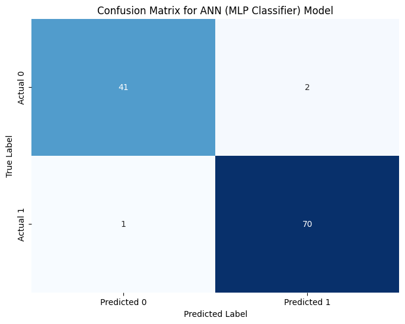

```python
plt.figure(figsize=(8, 6))
sns.heatmap(conf_matrix_mlp, annot=True, fmt='d', cmap='Blues', cbar=False,
            xticklabels=['Predicted 0', 'Predicted 1'],
            yticklabels=['Actual 0', 'Actual 1'])
plt.title('Confusion Matrix for ANN (MLP Classifier) Model')
plt.xlabel('Predicted Label')
plt.ylabel('True Label')
plt.show()
```

Inference: The confusion matrix for the ANN (MLP Classifier) model visually represents its performance on the test set. It shows the counts of true positive, true negative, false positive, and false negative predictions. This helps to understand where the model is performing well and where it is making errors in classifying breast cancer as malignant (0) or benign (1).